# Time Series Models

### VAR

The vector auto-regression (VAR) model extends the idea of uni-variate auto-regression to k time series regressions, where the lagged values of all k series appear as regressors. One the one hand, economic elements like GDP, investment and consumer spending, all depends upon interest rates. One the other hand, the level of interest rates is also set, in part, by the prospects for economic growth and inflation. Hence, we need a VAR model.

```r
rm(list=ls()) # clear workspace
cat("\014")  # clear console
```

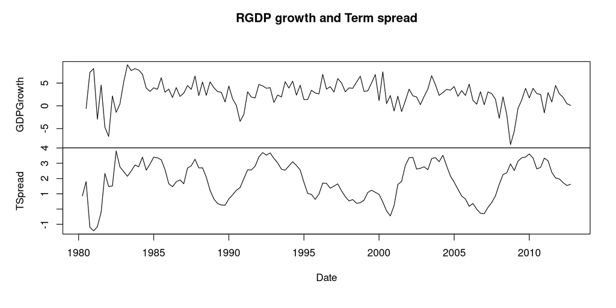

```r
library(Quandl)
Quandl_key = read.csv("quandlkey.csv",stringsAsFactors=FALSE)$Key
Quandl.api_key(Quandl_key)
startd <-"1980-04-01"
endd <-"2012-12-31"

TB3MS <- Quandl("FRED/TB3MS",start_date=startd, end_date=endd,type="ts")
TB10YS <- Quandl("FRED/GS10",start_date=startd, end_date=endd,type="ts")
GDP <- Quandl("FRED/GDPC96",start_date=startd, end_date=endd,type="ts", transform="rdiff")# note this is simple return, we need log return since we want to run regression

TSpread <- TB10YS - TB3MS
TSpread <- aggregate(TSpread,nfrequency=4,FUN=mean)# aggregate monthly data to quarterly(averages)
GDPGrowth = 400*log(1+GDP)# annual log growth rate%

# Visual inspection
plot(cbind(GDPGrowth, TSpread),xlab = "Date", main='RGDP growth and Term spread')
```

```r
library(vars)
### Step 1: Model selection (use information criteria to decide upon the number of lags to include)
VAR_Data<-na.omit(ts.union(GDPGrowth, TSpread)) #set up data for estimation
VARselect(VAR_Data, lag.max = 12, type = "const")$selection #obtain the best lag period
```

```
## AIC(n)  HQ(n)  SC(n) FPE(n)
##      2      2      2      2
```

```r
# Interpret: All the information criteria suggest using lags = 2 --> we need to set p=2 when estimating the model


### Step 2: Estimate VAR model
VAR_fit<-VAR(y = VAR_Data, p = 2)
summary(VAR_fit)
```

```
##
## VAR Estimation Results:
## =========================
## Endogenous variables: GDPGrowth, TSpread
## Deterministic variables: const
## Sample size: 128
## Log Likelihood: -381.122
## Roots of the characteristic polynomial:
## 0.8208 0.8208 0.1958 0.1958
## Call:
## VAR(y = VAR_Data, p = 2)
##
##
## Estimation results for equation GDPGrowth:
## ==========================================
## GDPGrowth = GDPGrowth.l1 + TSpread.l1 + GDPGrowth.l2 + TSpread.l2 + const
##
##              Estimate Std. Error t value Pr(>|t|)
## GDPGrowth.l1  0.29512    0.08356   3.532 0.000582 ***
## TSpread.l1   -0.87548    0.36949  -2.369 0.019373 *
## GDPGrowth.l2  0.21663    0.08173   2.651 0.009089 **
## TSpread.l2    1.29865    0.37148   3.496 0.000658 ***
## const         0.48692    0.47198   1.032 0.304256
## ---
## Signif. codes:  0 '***' 0.001 '**' 0.01 '*' 0.05 '.' 0.1 ' ' 1
##
##
## Residual standard error: 2.421 on 123 degrees of freedom
## Multiple R-Squared: 0.3111,  Adjusted R-squared: 0.2887
## F-statistic: 13.88 on 4 and 123 DF,  p-value: 2.246e-09
##
##
## Estimation results for equation TSpread:
## ========================================
## TSpread = GDPGrowth.l1 + TSpread.l1 + GDPGrowth.l2 + TSpread.l2 + const
##
##               Estimate Std. Error t value Pr(>|t|)
## GDPGrowth.l1  0.009302   0.017077   0.545 0.586944
## TSpread.l1    1.057695   0.075515  14.006  < 2e-16 ***
## GDPGrowth.l2 -0.056374   0.016703  -3.375 0.000988 ***
## TSpread.l2   -0.218659   0.075920  -2.880 0.004691 **
## const         0.454647   0.096461   4.713 6.48e-06 ***
## ---
## Signif. codes:  0 '***' 0.001 '**' 0.01 '*' 0.05 '.' 0.1 ' ' 1
##
##
## Residual standard error: 0.4948 on 123 degrees of freedom
## Multiple R-Squared: 0.8304,  Adjusted R-squared: 0.8249
## F-statistic: 150.6 on 4 and 123 DF,  p-value: < 2.2e-16
##
##
##
## Covariance matrix of residuals:
##           GDPGrowth TSpread
## GDPGrowth   5.86218 0.05959
## TSpread     0.05959 0.24486
##
## Correlation matrix of residuals:
##           GDPGrowth TSpread
## GDPGrowth   1.00000 0.04974
## TSpread     0.04974 1.00000
```

Our estimate functions are:

$$\begin{align}
GDPgrowth_t &= c_1 + \alpha_{11}GDPGrowth_{t-1} +
\alpha_{12}TSpread_{t-1} + \alpha_{13}GDPGrowth_{t-2} +
\alpha_{14}TSpread_{t-2} ~~~(1)\\
TSpread_t &= c_2 + \alpha_{21}GDPGrowth_{t-1} +
\alpha_{22}TSpread_{t-1} + \alpha_{23}GDPGrowth_{t-2} +
\alpha_{24}TSpread_{t-2} ~~~(2)
\end{align}$$

In this first equation, the a11 coefficient = 0.295 implies that for every one unit increase in the last quarter GDP growth rate, GDP this quarter will rise by .295, holding constant the dynamic effects of prior GDP growth and the Term Spread. Meanwhile, the a12 coefficient = -0.875 implies that every one unit increase in the last quarter Term Spread will cause GDP growth this quarter to fall by .875 units.

Now Let’s look at the second equation. a21 = 0.009 implies that for every one unit increase in the last quarter GDP growth rate, Term Spread this quarter will rise by .009. Likewise, the a22 = 1.058 implies that a unit increase in the last quarter Term Spread will cause Term Spread this quarter to rise by 1.058 units.

However, since each coefficient in the VAR model only reflects a partial dynamic relationship and cannot capture a comprehensive dynamic relationship, we may need other tools such as Granger causality test, IRF impulse response function to help us understand the relationships.

```r
# Obtain the adj. R^2 from the output of 'VAR()'
summary(VAR_fit$varresult$GDPGrowth)$adj.r.squared
```

```
## [1] 0.2886718
```

```r
summary(VAR_fit$varresult$TSpread)$adj.r.squared
```

```
## [1] 0.824881
```

```r
# Multi-step forecast
predictions <- predict(VAR_fit,n.ahead = 15, ci = 0.95)
predictions
```

```
## $GDPGrowth
##           fcst     lower    upper       CI
##  [1,] 1.198711 -3.546741 5.944163 4.745452
##  [2,] 1.383492 -3.624828 6.391812 5.008320
##  [3,] 1.734391 -3.469314 6.938096 5.203705
##  [4,] 2.045169 -3.266459 7.356797 5.311628
##  [5,] 2.304776 -3.077621 7.687172 5.382396
##  [6,] 2.514830 -2.924988 7.954647 5.439817
##  [7,] 2.674189 -2.814666 8.163044 5.488855
##  [8,] 2.787256 -2.742916 8.317427 5.530171
##  [9,] 2.860470 -2.702736 8.423677 5.563207
## [10,] 2.901204 -2.686752 8.489160 5.587956
## [11,] 2.916929 -2.688342 8.522199 5.605271
## [12,] 2.914597 -2.701976 8.531170 5.616573
## [13,] 2.900280 -2.723177 8.523737 5.623457
```

[output cut: 20 more lines]

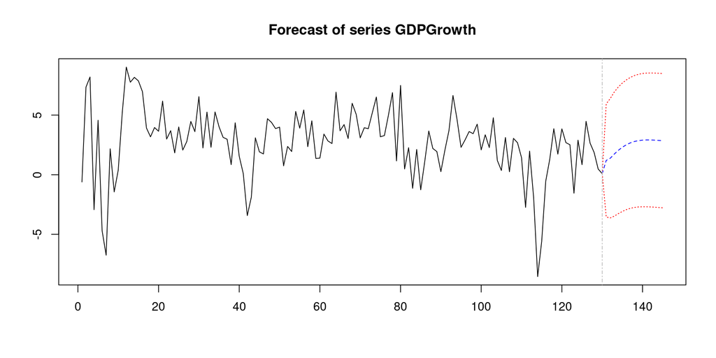

```r
plot(predictions, names = "GDPGrowth")
```

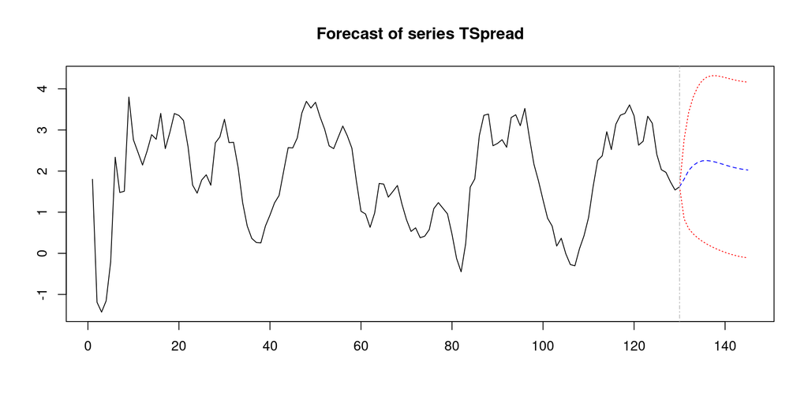

```r
plot(predictions, names = "TSpread")
```

### Test the Direction of Causality

#### Test the Direction of Causality Using `causality()`

```r
rm(list=ls()) # clear workspace
cat("\014")  # clear console
```

```r
library(Quandl)
Quandl_key = read.csv("quandlkey.csv",stringsAsFactors=FALSE)$Key
Quandl.api_key(Quandl_key)
startd <-"1980-04-01"
endd <-"2012-12-31"

TB3MS <- Quandl("FRED/TB3MS",start_date=startd, end_date=endd,type="ts")
TB10YS <- Quandl("FRED/GS10",start_date=startd, end_date=endd,type="ts")
GDP <- Quandl("FRED/GDPC96",start_date=startd, end_date=endd,type="ts", transform="rdiff")# note this is simple return, we need log return since we want to run regression

TSpread <- TB10YS - TB3MS
TSpread <- aggregate(TSpread,nfrequency=4,FUN=mean)# aggregate monthly data to quarterly(averages)
GDPGrowth = 400*log(1+GDP)# annual log growth rate%

### VAR Model
library(vars)
VAR_Data<-na.omit(ts.union(GDPGrowth, TSpread)) #set up data for estimation
VARselect(VAR_Data, lag.max = 12, type = "const")$selection #obtain the best lag period
```

```
## AIC(n)  HQ(n)  SC(n) FPE(n)
##      2      2      2      2
```

```r
VAR_fit<-VAR(y = VAR_Data, p = 2)
summary(VAR_fit)
```

```
##
## VAR Estimation Results:
## =========================
## Endogenous variables: GDPGrowth, TSpread
## Deterministic variables: const
## Sample size: 128
## Log Likelihood: -381.122
## Roots of the characteristic polynomial:
## 0.8208 0.8208 0.1958 0.1958
## Call:
## VAR(y = VAR_Data, p = 2)
##
##
## Estimation results for equation GDPGrowth:
## ==========================================
## GDPGrowth = GDPGrowth.l1 + TSpread.l1 + GDPGrowth.l2 + TSpread.l2 + const
##
##              Estimate Std. Error t value Pr(>|t|)
## GDPGrowth.l1  0.29512    0.08356   3.532 0.000582 ***
## TSpread.l1   -0.87548    0.36949  -2.369 0.019373 *
## GDPGrowth.l2  0.21663    0.08173   2.651 0.009089 **
## TSpread.l2    1.29865    0.37148   3.496 0.000658 ***
## const         0.48692    0.47198   1.032 0.304256
## ---
## Signif. codes:  0 '***' 0.001 '**' 0.01 '*' 0.05 '.' 0.1 ' ' 1
##
##
## Residual standard error: 2.421 on 123 degrees of freedom
## Multiple R-Squared: 0.3111,  Adjusted R-squared: 0.2887
## F-statistic: 13.88 on 4 and 123 DF,  p-value: 2.246e-09
##
##
## Estimation results for equation TSpread:
## ========================================
## TSpread = GDPGrowth.l1 + TSpread.l1 + GDPGrowth.l2 + TSpread.l2 + const
##
##               Estimate Std. Error t value Pr(>|t|)
## GDPGrowth.l1  0.009302   0.017077   0.545 0.586944
## TSpread.l1    1.057695   0.075515  14.006  < 2e-16 ***
## GDPGrowth.l2 -0.056374   0.016703  -3.375 0.000988 ***
## TSpread.l2   -0.218659   0.075920  -2.880 0.004691 **
## const         0.454647   0.096461   4.713 6.48e-06 ***
## ---
## Signif. codes:  0 '***' 0.001 '**' 0.01 '*' 0.05 '.' 0.1 ' ' 1
##
##
## Residual standard error: 0.4948 on 123 degrees of freedom
## Multiple R-Squared: 0.8304,  Adjusted R-squared: 0.8249
## F-statistic: 150.6 on 4 and 123 DF,  p-value: < 2.2e-16
##
##
##
## Covariance matrix of residuals:
##           GDPGrowth TSpread
## GDPGrowth   5.86218 0.05959
## TSpread     0.05959 0.24486
##
## Correlation matrix of residuals:
##           GDPGrowth TSpread
## GDPGrowth   1.00000 0.04974
## TSpread     0.04974 1.00000
```

```r
### Granger Causality Tests
# H0: GDPGrowth does not Granger-cause TSpread (GDPGrowth is not the cause varaible) <=> H0: a21 = a23 = 0
causality(VAR_fit, cause = "GDPGrowth")$Granger
```

```
##
##  Granger causality H0: GDPGrowth do not Granger-cause TSpread
##
## data:  VAR object VAR_fit
## F-Test = 6.1452, df1 = 2, df2 = 246, p-value = 0.002487
```

```r
# H0: TSpread does not ranger-cause GDPGrowth (TSpread is not the cause varaible) <=> H0: a12 = a14 = 0
causality(VAR_fit, cause = "TSpread")$Granger
```

```
##
##  Granger causality H0: TSpread do not Granger-cause GDPGrowth
##
## data:  VAR object VAR_fit
## F-Test = 7.1708, df1 = 2, df2 = 246, p-value = 0.00094
```

#### Test the Direction of Causality Using `linearHypothesis()`

```r
rm(list=ls()) # clear workspace
cat("\014")  # clear console
```

```r
library(Quandl)
Quandl_key = read.csv("quandlkey.csv",stringsAsFactors=FALSE)$Key
Quandl.api_key(Quandl_key)
startd <-"1980-04-01"
endd <-"2012-12-31"

TB3MS <- Quandl("FRED/TB3MS",start_date=startd, end_date=endd,type="ts")
TB10YS <- Quandl("FRED/GS10",start_date=startd, end_date=endd,type="ts")
GDP <- Quandl("FRED/GDPC96",start_date=startd, end_date=endd,type="ts", transform="rdiff")# note this is simple return, we need log return since we want to run regression

TSpread <- TB10YS - TB3MS
TSpread <- aggregate(TSpread,nfrequency=4,FUN=mean)# aggregate monthly data to quarterly(averages)
GDPGrowth = 400*log(1+GDP)# annual log growth rate%

### Model selection
VAR_Data<-na.omit(ts.union(GDPGrowth, TSpread)) #set up data for estimation
VARselect(VAR_Data, lag.max = 12, type = "const")$selection #obtain the best lag period
```

```
## AIC(n)  HQ(n)  SC(n) FPE(n)
##      2      2      2      2
```

```r
# Interpret: All the information criteria suggest using lags = 2 --> we need to set p=2 when estimating the mod


### Estimate VAR equations separately by OLS
library(dynlm)
VAR_EQ1<-dynlm(GDPGrowth ~ L(GDPGrowth, 1:2) + L(TSpread, 1:2), start=c(1981,1), end=c(2012,4))
VAR_EQ2<-dynlm(TSpread ~ L(GDPGrowth, 1:2) + L(TSpread, 1:2), start=c(1981,1), end=c(2012,4))
# Rename regressors for better readability
names(VAR_EQ1$coefficients) <- c("Intercept","Growth_t-1", "Growth_t-2", "TSpread_t-1", "TSpread_t-2")
names(VAR_EQ2$coefficients) <- names(VAR_EQ1$coefficients)

# Obtain Robust Coefficient
library(lmtest)
library(sandwich)
coeftest(VAR_EQ1, vcov. = sandwich)
```

```
##
## t test of coefficients:
##
##              Estimate Std. Error t value Pr(>|t|)
## Intercept    0.486924   0.523771  0.9297 0.354373
## Growth_t-1   0.295117   0.109974  2.6835 0.008288 **
## Growth_t-2   0.216634   0.086355  2.5086 0.013421 *
## TSpread_t-1 -0.875477   0.361088 -2.4246 0.016781 *
## TSpread_t-2  1.298647   0.395225  3.2858 0.001325 **
## ---
## Signif. codes:  0 '***' 0.001 '**' 0.01 '*' 0.05 '.' 0.1 ' ' 1
```

```r
coeftest(VAR_EQ2, vcov. = sandwich)
```

```
##
## t test of coefficients:
##
##               Estimate Std. Error t value  Pr(>|t|)
## Intercept    0.4546467  0.1214656  3.7430 0.0002778 ***
## Growth_t-1   0.0093019  0.0218258  0.4262 0.6707140
## Growth_t-2  -0.0563737  0.0266037 -2.1190 0.0360996 *
## TSpread_t-1  1.0576951  0.0984832 10.7399 < 2.2e-16 ***
## TSpread_t-2 -0.2186588  0.1088367 -2.0091 0.0467207 *
## ---
## Signif. codes:  0 '***' 0.001 '**' 0.01 '*' 0.05 '.' 0.1 ' ' 1
```

```r
### Granger causality tests
library(car)
# H0: X does not Granger Cause Y
linearHypothesis(VAR_EQ1,
                 hypothesis.matrix = c("TSpread_t-1", "TSpread_t-2"),
                 vcov. = sandwich)
```

```
## Linear hypothesis test
##
## Hypothesis:
## TSpread_t - 0
## TSpread_t - 2 = 0
##
## Model 1: restricted model
## Model 2: GDPGrowth ~ L(GDPGrowth, 1:2) + L(TSpread, 1:2)
##
## Note: Coefficient covariance matrix supplied.
##
##   Res.Df Df      F   Pr(>F)
## 1    125
## 2    123  2 5.5884 0.004753 **
## ---
## Signif. codes:  0 '***' 0.001 '**' 0.01 '*' 0.05 '.' 0.1 ' ' 1
```

```r
linearHypothesis(VAR_EQ2,
                 hypothesis.matrix = c("Growth_t-1", "Growth_t-2"),
                 vcov. = sandwich)
```

```
## Linear hypothesis test
##
## Hypothesis:
## Growth_t - 0
## Growth_t - 2 = 0
##
## Model 1: restricted model
## Model 2: TSpread ~ L(GDPGrowth, 1:2) + L(TSpread, 1:2)
##
## Note: Coefficient covariance matrix supplied.
##
##   Res.Df Df      F  Pr(>F)
## 1    125
## 2    123  2 3.3739 0.03746 *
## ---
## Signif. codes:  0 '***' 0.001 '**' 0.01 '*' 0.05 '.' 0.1 ' ' 1
```

```r
# Interpret: Both Granger causality tests reject at the level of 5%, this is evidence in favor of the conjecture that the term spread has power in explaining GDP growth and vice versa
```